# NYPD Crime Stats

2023-04-29

# NYPD Shooting Incidents Data Analysis

The New York City Police Department has a publicly available data set of data shooting incidents. This data set commences in 2006 and is updated after the end of each calendar year. The data source can be found at the link below.

### Data Source

[NYPD Shooting Incidents Data](https://catalog.data.gov/dataset/nypd-shooting-incident-data-historic)

#### Data Source details

The data set details four primary areas of description of the shooting incidents.  
1. Victims’ demographic profile 2. Perpetrators’ demographic profile 3. Location descriptors of where the incident occurred 4. A designation of the incident’s crime type - Murder vs. Non-Murder

# Focus of Analysis

The below analysis will focus on the time attributes of a shooting as well as where the shooting occurred. It will explore whether those attributes correlate with whether the shooting resulted in a Murder.

#### Load Libraries

Loading the required libraries for analysis

```r
library(tidyverse)
library(lubridate)
```

#### Load Data

Loading the data directly from the website

```r
url_data = "https://data.cityofnewyork.us/api/views/833y-fsy8/rows.csv?accessType=DOWNLOAD"
nypd_df = read_csv(url_data)
```

#### Display Initial Data Summary Statistics

Initial examination of the data to explore the fields and explore data scrubbing requirements

```r
dim(nypd_df)
```

```
## [1] 27312    21
```

```r
summary(nypd_df)
```

```
##   INCIDENT_KEY        OCCUR_DATE         OCCUR_TIME           BORO
##  Min.   :  9953245   Length:27312       Length:27312      Length:27312
##  1st Qu.: 63860880   Class :character   Class1:hms        Class :character
##  Median : 90372218   Mode  :character   Class2:difftime   Mode  :character
##  Mean   :120860536                      Mode  :numeric
##  3rd Qu.:188810230
##  Max.   :261190187
##
##  LOC_OF_OCCUR_DESC     PRECINCT      JURISDICTION_CODE LOC_CLASSFCTN_DESC
##  Length:27312       Min.   :  1.00   Min.   :0.0000    Length:27312
##  Class :character   1st Qu.: 44.00   1st Qu.:0.0000    Class :character
##  Mode  :character   Median : 68.00   Median :0.0000    Mode  :character
##                     Mean   : 65.64   Mean   :0.3269
##                     3rd Qu.: 81.00   3rd Qu.:0.0000
##                     Max.   :123.00   Max.   :2.0000
##                                      NA's   :2
##  LOCATION_DESC      STATISTICAL_MURDER_FLAG PERP_AGE_GROUP
##  Length:27312       Mode :logical           Length:27312
##  Class :character   FALSE:22046             Class :character
##  Mode  :character   TRUE :5266              Mode  :character
##
##
##
##
##    PERP_SEX          PERP_RACE         VIC_AGE_GROUP        VIC_SEX
##  Length:27312       Length:27312       Length:27312       Length:27312
##  Class :character   Class :character   Class :character   Class :character
##  Mode  :character   Mode  :character   Mode  :character   Mode  :character
##
##
##
##
##    VIC_RACE           X_COORD_CD        Y_COORD_CD        Latitude
##  Length:27312       Min.   : 914928   Min.   :125757   Min.   :40.51
##  Class :character   1st Qu.:1000028   1st Qu.:182834   1st Qu.:40.67
##  Mode  :character   Median :1007731   Median :194487   Median :40.70
##                     Mean   :1009449   Mean   :208127   Mean   :40.74
##                     3rd Qu.:1016838   3rd Qu.:239518   3rd Qu.:40.82
##                     Max.   :1066815   Max.   :271128   Max.   :40.91
##                                                        NA's   :10
##    Longitude        Lon_Lat
##  Min.   :-74.25   Length:27312
##  1st Qu.:-73.94   Class :character
##  Median :-73.92   Mode  :character
##  Mean   :-73.91
##  3rd Qu.:-73.88
##  Max.   :-73.70
##  NA's   :10
```

# Data Scrubbing

Below are series of steps to modify the data into data types that are more amenable to statistical analysis, as well as create various groupings of or pivot tables that allow for further exploration.

#### Data Scrub #1 Convert Date fields to Date Objects

```r
nypd_df$OCCUR_DATE <- mdy(nypd_df$OCCUR_DATE)
```

#### Data Scrub #2 Convert Descriptive Variables to Categorical

```r
nypd_df$PERP_SEX <- factor(nypd_df$PERP_SEX)
nypd_df$PERP_RACE <- factor(nypd_df$PERP_RACE)
nypd_df$VIC_SEX <- factor(nypd_df$VIC_SEX)
nypd_df$VIC_RACE <- factor(nypd_df$VIC_RACE)
```

#### Data Scrub #3 Convert Descriptive Variables to Ordinal

```r
nypd_df$PERP_AGE_GROUP <- factor(nypd_df$PERP_AGE_GROUP, order = TRUE,
                      levels = c('<18', '18-24',  '25-44', '45-64', '65+'))
nypd_df$VIC_AGE_GROUP <- factor(nypd_df$VIC_AGE_GROUP, order = TRUE,
                      levels = c('<18', '18-24',  '25-44', '45-64', '65+'))
```

#### Data Scrub #4 Add Categorical Variables for Murder Boolean & Boro

```r
nypd_df$BORO_CAT <- factor(nypd_df$BORO)
nypd_df$MURDER_CAT <- as.integer(nypd_df$STATISTICAL_MURDER_FLAG)
```

##### Data Scrub #5 Extract Hour of incident

```r
nypd_df$HOUR <- strftime(nypd_df$OCCUR_TIME, "%H")
```

#### Data Scrub #6 Extract Month & Day of Week

```r
nypd_df$MONTH <- strftime(nypd_df$OCCUR_DATE,"%m")
```

```r
nypd_df$MONTH <- strftime(nypd_df$OCCUR_DATE,"%m")
nypd_df$DOWEEK <-strftime(nypd_df$OCCUR_DATE, "%w")
```

#### Data Scrub #7 Group by Date

```r
daily_incidents <- nypd_df %>% group_by(OCCUR_DATE) %>% summarise(INCIDENT_COUNT = n())
head(daily_incidents)
```

```
## # A tibble: 6 × 2
##   OCCUR_DATE INCIDENT_COUNT
##   <date>              <int>
## 1 2006-01-01              8
## 2 2006-01-02              4
## 3 2006-01-03              4
## 4 2006-01-04              4
## 5 2006-01-05              4
## 6 2006-01-06              4
```

#### Data Scrub #8 Group by Boro

```r
boro_df <- nypd_df %>%
 group_by(BORO) %>%
 summarize(MURDERS = sum(MURDER_CAT), INCIDENTS = n())
boro_df$NON_MURDERS = boro_df$INCIDENTS - boro_df$MURDERS
boro_df$MURDER_PTGE = boro_df$MURDERS / boro_df$INCIDENTS
```

#### Data Scrub #9 Group by Month

```r
monthly_incidents <- daily_incidents %>%
     group_by(MONTH = lubridate::floor_date(OCCUR_DATE, "month")) %>%
     summarize(MONTHLY_COUNT = sum(INCIDENT_COUNT))
monthly_incidents$MONTH_NAME <- format(monthly_incidents$MONTH,"%B")
```

```r
head(monthly_incidents)
```

```
## # A tibble: 6 × 3
##   MONTH      MONTHLY_COUNT MONTH_NAME
##   <date>             <int> <chr>
## 1 2006-01-01           129 January
## 2 2006-02-01            97 February
## 3 2006-03-01           102 March
## 4 2006-04-01           156 April
## 5 2006-05-01           173 May
## 6 2006-06-01           180 June
```

```r
month_df <- monthly_incidents %>%
     group_by(MONTH_NAME) %>%
     summarise(AVG_ICEN = mean(MONTHLY_COUNT), MIN_ICEN = min(MONTHLY_COUNT),
               MAX_ICEN = max(MONTHLY_COUNT), MED_ICEN = median(MONTHLY_COUNT))
```

#### Data Scrub #10 Create Weekday Variable and Month Variable in daily_incidents

```r
daily_incidents$DAY_NUM <- wday(daily_incidents$OCCUR_DATE, week_start=1)
daily_incidents$DAY_LAB <- wday(daily_incidents$OCCUR_DATE, label=TRUE)
daily_incidents$MONTH_NUM <- strftime(daily_incidents$OCCUR_DATE, "%m")
daily_incidents$MONTH_NUM <- as.numeric(daily_incidents$MONTH_NUM)
head(daily_incidents)
```

```
## # A tibble: 6 × 5
##   OCCUR_DATE INCIDENT_COUNT DAY_NUM DAY_LAB MONTH_NUM
##   <date>              <int>   <dbl> <ord>       <dbl>
## 1 2006-01-01              8       7 Sun             1
## 2 2006-01-02              4       1 Mon             1
## 3 2006-01-03              4       2 Tue             1
## 4 2006-01-04              4       3 Wed             1
## 5 2006-01-05              4       4 Thu             1
## 6 2006-01-06              4       5 Fri             1
```

#### Data Scrub #11 Group by Day of Week

```r
weekday_incidents <- daily_incidents %>%
     group_by(DAY_LAB) %>%
     summarise(WEEKDAY_COUNT = sum(INCIDENT_COUNT))
     weekday_incidents
```

```
## # A tibble: 7 × 2
##   DAY_LAB WEEKDAY_COUNT
##   <ord>           <int>
## 1 Sun              5452
## 2 Mon              3883
## 3 Tue              3163
## 4 Wed              3000
## 5 Thu              3034
## 6 Fri              3585
## 7 Sat              5195
```

# Plotting

Next, create plots and graphs that explore the data, focusing primarily on the Location and Time of the incident.

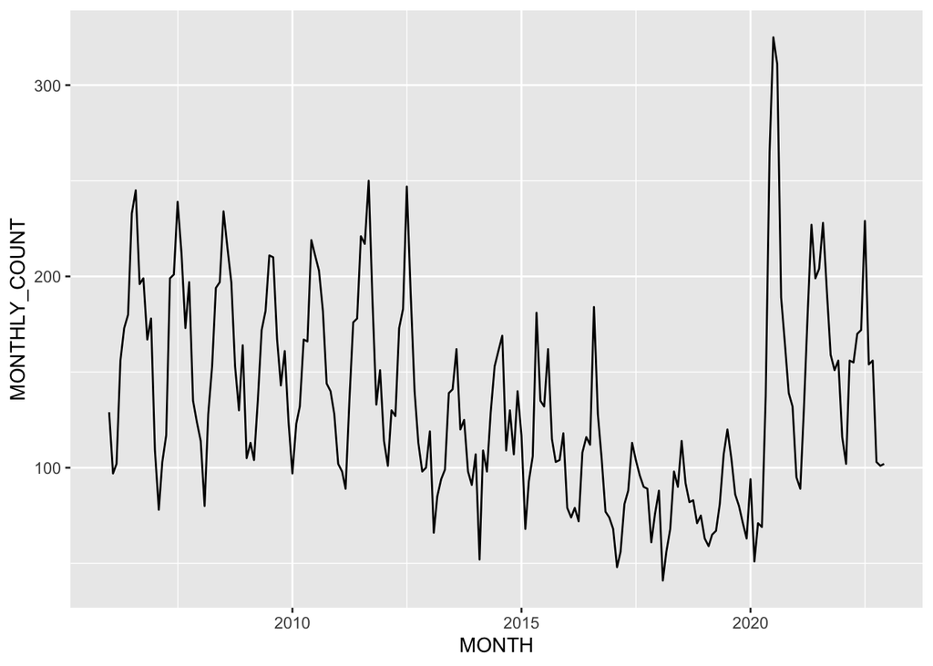

```r
ggplot(monthly_incidents,aes(x = MONTH, y = MONTHLY_COUNT)) + geom_line()
```

#### Violin Plot of Incidents aggregated by Calendar Monthly Incidents

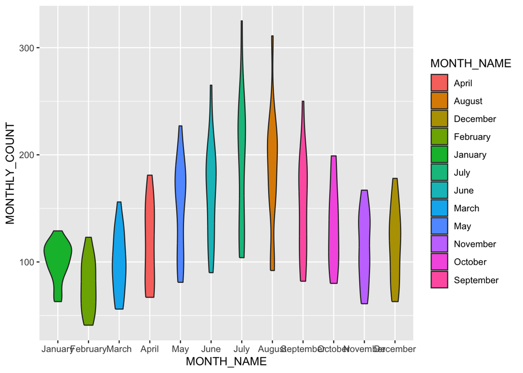

```r
ggplot(data=monthly_incidents, aes(x=MONTH_NAME, y=MONTHLY_COUNT,
                                   fill=MONTH_NAME)) +
geom_violin() +
  scale_x_discrete(limits=c("January","February","March","April","May","June",
                  "July","August","September","October","November","December"))
```

#### Graph Murder vs Non-Murder Incidents by Boro

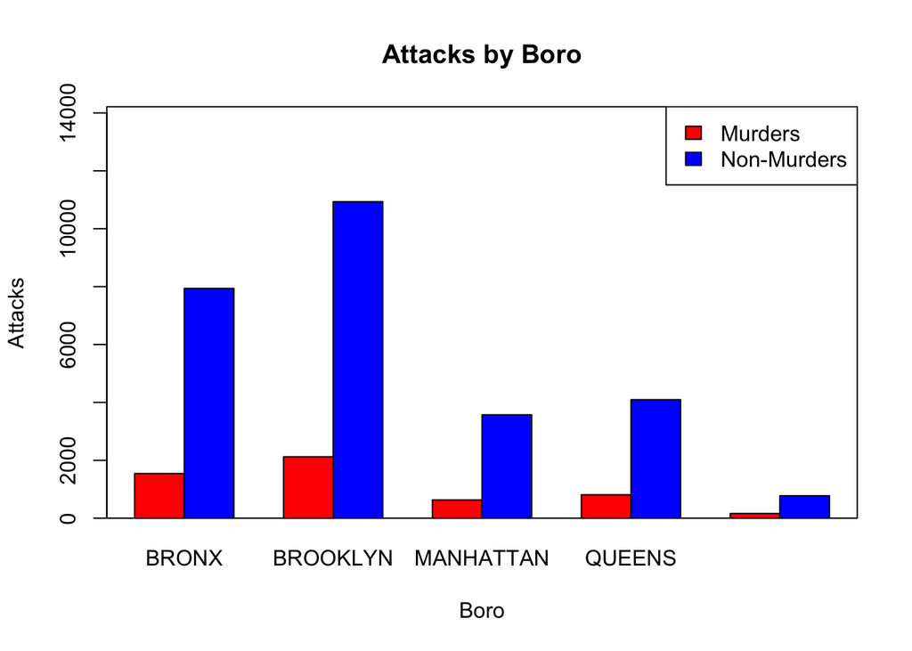

```r
colours = c("red","blue")
mx <- t(as.matrix(boro_df %>% select(2,3)))
colnames(mx) <- boro_df$BORO
barplot(mx, main='Attacks by Boro', ylab='Attacks', xlab='Boro', beside = TRUE, col=colours,ylim=c(0,max(mx)*1.3))
box()
legend('topright',fill=colours,legend=c('Murders','Non-Murders'))
```

This graph show a consistent ratio of Murder to Non-Murders amongst the boroughs. Curiously, Queens has far fewer incidents than Brooklyn, even though those two boroughs are the only that share a land border.

#### Bias

When dealing with human demographic data Bias is a large concern. In contrast, my analysis has focused on the Time and Location implications of Incidents. Bias could still be present in the data points upon which I focused. One possible example is the reporting of crime statistics. Certain victims maybe more or less likely to report themselves as the victim of crime to the police.

#### Logistic Model Goal

I opted to try to create a Logistic Model to analyze what factors may correlate with an Incident being a Murder vs Non-Murder. To accomplish this I a “Murder Category” Column by converted the Murder-Statistical-Flag from a True/False Boolean to either 1 / 0 (1 = Murder).

I selected the Categorial version of the variables of - Calendar-Month, Day-of-Week, & Boro (large neighborhood).

#### Create Logistic Model

```r
mylogit <- glm(MURDER_CAT ~ BORO_CAT + MONTH + DOWEEK + HOUR, data = nypd_df, family = "binomial")
summary(mylogit)
```

```
##
## Call:
## glm(formula = MURDER_CAT ~ BORO_CAT + MONTH + DOWEEK + HOUR,
##     family = "binomial", data = nypd_df)
##
## Coefficients:
##                        Estimate Std. Error z value Pr(>|z|)
## (Intercept)           -1.481793   0.090203 -16.427  < 2e-16 ***
## BORO_CATBROOKLYN      -0.007241   0.037482  -0.193 0.846817
## BORO_CATMANHATTAN     -0.115915   0.052497  -2.208 0.027243 *
## BORO_CATQUEENS         0.018036   0.048714   0.370 0.711197
## BORO_CATSTATEN ISLAND  0.068945   0.093247   0.739 0.459675
## MONTH02                0.063245   0.090885   0.696 0.486500
## MONTH03               -0.017736   0.086768  -0.204 0.838035
## MONTH04                0.014256   0.083034   0.172 0.863684
## MONTH05                0.018671   0.078766   0.237 0.812619
## MONTH06               -0.108625   0.078564  -1.383 0.166777
## MONTH07               -0.110275   0.076642  -1.439 0.150196
## MONTH08               -0.145543   0.077306  -1.883 0.059743 .
## MONTH09                0.051864   0.078319   0.662 0.507830
## MONTH10                0.010567   0.080523   0.131 0.895593
## MONTH11               -0.020704   0.083820  -0.247 0.804905
## MONTH12                0.166564   0.081297   2.049 0.040479 *
## DOWEEK1                0.028303   0.054374   0.521 0.602696
## DOWEEK2               -0.013272   0.058384  -0.227 0.820177
## DOWEEK3                0.127123   0.057991   2.192 0.028372 *
## DOWEEK4                0.050718   0.058520   0.867 0.386123
## DOWEEK5                0.063210   0.055486   1.139 0.254617
## DOWEEK6               -0.053258   0.050181  -1.061 0.288544
## HOUR01                -0.038097   0.080297  -0.474 0.635175
## HOUR02                -0.038562   0.083477  -0.462 0.644118
## HOUR03                -0.052081   0.086329  -0.603 0.546320
## HOUR04                 0.142560   0.086297   1.652 0.098541 .
## HOUR05                 0.398083   0.104235   3.819 0.000134 ***
## HOUR06                 0.340852   0.135215   2.521 0.011708 *
## HOUR07                 0.664242   0.153142   4.337 1.44e-05 ***
## HOUR08                 0.464982   0.156975   2.962 0.003055 **
## HOUR09                 0.282679   0.170108   1.662 0.096560 .
## HOUR10                 0.260546   0.147678   1.764 0.077684 .
## HOUR11                 0.359638   0.132595   2.712 0.006682 **
## HOUR12                 0.245697   0.121618   2.020 0.043359 *
## HOUR13                 0.262175   0.114202   2.296 0.021693 *
## HOUR14                 0.128163   0.104657   1.225 0.220726
## HOUR15                -0.076215   0.103194  -0.739 0.460173
## HOUR16                -0.265291   0.103859  -2.554 0.010639 *
## HOUR17                 0.097127   0.094745   1.025 0.305296
## HOUR18                 0.237704   0.088242   2.694 0.007065 **
## HOUR19                 0.014987   0.087271   0.172 0.863653
## HOUR20                -0.090906   0.085613  -1.062 0.288313
## HOUR21                 0.063287   0.079995   0.791 0.428865
## HOUR22                 0.140317   0.077374   1.813 0.069758 .
## HOUR23                -0.105998   0.079114  -1.340 0.180308
## ---
## Signif. codes:  0 '***' 0.001 '**' 0.01 '*' 0.05 '.' 0.1 ' ' 1
##
## (Dispersion parameter for binomial family taken to be 1)
##
##     Null deviance: 26781  on 27311  degrees of freedom
## Residual deviance: 26611  on 27267  degrees of freedom
## AIC: 26701
##
## Number of Fisher Scoring iterations: 4
```